# Synaptome Stats: Marker Exploration

Jesse Leigh Patsolic

2016-07-12

[Homepage](http://docs.neurodata.io/synaptome-stats/)  
The formatted source code for this file is [here](https://github.com/neurodata/synaptome-stats/blob/gh-pages/Code/MarkerExploration.Rmd).  
And a raw version [here](https://raw.githubusercontent.com/neurodata/synaptome-stats/gh-pages/Code/MarkerExploration.Rmd).  
Previous work by Youngser Park can be found [here](http://www.cis.jhu.edu/~parky/Synapse/synapse.html).

# 1 Data

Here we read in the data and select a random half of it for exploration.

```r
featFull <- fread("../data/synapsinR_7thA.tif.Pivots.txt.2011Features.txt",showProgress=FALSE)

### Setting a seed and creating an index vector
### to select half of the data
set.seed(2^10)
half1 <- sample(dim(featFull)[1],dim(featFull)[1]/2)
half2 <- setdiff(1:dim(featFull)[1],half1)

feat <- featFull[half1,]
dim(feat)
```

```
# [1] 559649    144
```

```r
## Setting the channel names
channel <- c('Synap_1','Synap_2','VGlut1_t1','VGlut1_t2','VGlut2','Vglut3',
              'psd','glur2','nmdar1','nr2b','gad','VGAT',
              'PV','Gephyr','GABAR1','GABABR','CR1','5HT1A',
              'NOS','TH','VACht','Synapo','tubuli','DAPI')

## Setting the channel types
channel.type <- c('ex.pre','ex.pre','ex.pre','ex.pre','ex.pre','in.pre.small',
                  'ex.post','ex.post','ex.post','ex.post','in.pre','in.pre',
                  'in.pre','in.post','in.post','in.post','in.pre.small','other',
                  'ex.post','other','other','ex.post','none','none')

channel.type2 <- c('ex.pre','ex.pre','ex.pre','ex.pre','ex.pre','other',
                   'ex.post','ex.post','ex.post','ex.post','in.pre','in.pre',
                   'in.pre','in.post','in.post','in.post','other','other',
                   'ex.post','other','other','ex.post','other','other')
nchannel <- length(channel)
nfeat <- ncol(feat) / nchannel

## Createing factor variables for channel and channel type sorted properly
ffchannel <- (factor(channel.type,
    levels= c("ex.pre","ex.post","in.pre","in.post","in.pre.small","other","none")
    ))
fchannel <- as.numeric(factor(channel.type,
    levels= c("ex.pre","ex.post","in.pre","in.post","in.pre.small","other","none")
    ))
ford <- order(fchannel)


## Setting up colors for channel types
Syncol <-  c("#197300","#5ed155","#660000","#cc0000","#ff9933","#0000cd","#ffd700")
Syncol3 <- c("#197300","#197300","#cc0000","#cc0000","#0000cd","#0000cd","#0000cd")
ccol <- Syncol[fchannel]
ccol3 <- Syncol3[fchannel]

exType <- factor(c(rep("ex",11),rep("in",6),rep("other",7)),ordered=TRUE)
exCol<-exType;levels(exCol) <- c("#197300","#990000","#0000cd");
exCol <- as.character(exCol)

fname <- as.vector(sapply(channel,function(x) paste0(x,paste0("F",0:5))))
names(feat) <- fname
fcol <- rep(ccol, each=6)
mycol <- colorpanel(100, "purple", "black", "green")
mycol2 <- matlab.like(nchannel)
mycol3 <- colorpanel(100, "blue","white","red")
```

## 1.1 Data transformations

```r
f <- lapply(1:6,function(x){seq(x,ncol(feat),by=nfeat)})
featF <- lapply(f,function(x){subset(feat,select=x)})

featF0 <- featF[[1]]
f01e3 <- 1e3*data.table(apply(X=featF0,2,function(x){((x-min(x))/(max(x)-min(x)))}))

fs <- f01e3

### Taking log_10 on data + 1.
log1f <- log10(featF0 + 1)
slog1f <- data.table(scale(log1f, center=TRUE,scale=TRUE))
```

We now have the following data sets:

- `featF0`: The feature vector looking only at the integrated brightness features.
- `fs`: The feature vector scaled between $[0,1000]$.
- `logf1`: The feature vector, plus one, then $log_{10}$ is applied.
- `slog1f`: The feature vector, plus one, $log_{10}$, then scaled by subtracting the mean and dividing by the sample standard deviation.

# 2 Marker Exploration

## 2.1 Correlation Matrix of markers

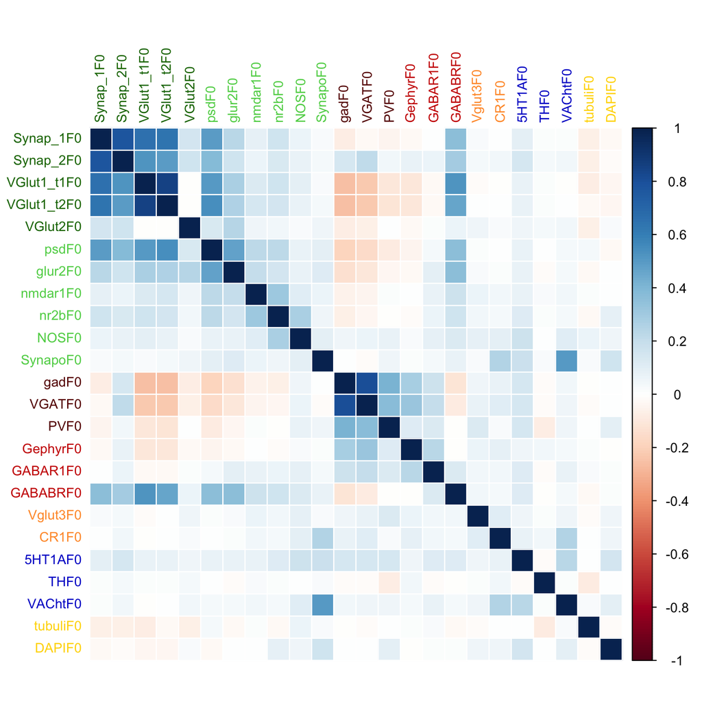

**Figure 1: Correlation on untransformed F0 data, reordered by synapse type.**

```r
corrf <- cor(featF[[1]])[ford,ford]
corrplot(corrf,method="color",tl.col=ccol[ford], tl.cex=0.8)
```

```r
corLog <- cor(slog1f)
```

## 2.2 Energy Matrix: Distance Correlation T-test

```r
set.seed(317)
sam1 <- sample(dim(featF0)[1], 1e3)
tmp <- as.data.frame((featF0[sam1,]))

set.seed(331)
combcols <- t(combn(24,2))

dc <- foreach(i = 1:dim(combcols)[1]) %dopar% {
       #dcov.test(x=tmp[,combcols[i,1]],y=tmp[,combcols[i,2]])
       dcor.ttest(x=tmp[,combcols[i,1]],y=tmp[,combcols[i,2]])
       }

ms <- matrix(as.numeric(0),24,24)
mp <- matrix(as.numeric(0),24,24)

for(i in 1:length(dc)){
    ms[combcols[i,1],combcols[i,2]] <- dc[[i]]$statistic
    ms[combcols[i,2],combcols[i,1]] <- dc[[i]]$statistic
    mp[combcols[i,1],combcols[i,2]] <- dc[[i]]$p.val
    mp[combcols[i,2],combcols[i,1]] <- dc[[i]]$p.val
}

rownames(ms) <- colnames(featF0)
rownames(mp) <- colnames(featF0)
colnames(ms) <- colnames(featF0)
colnames(mp) <- colnames(featF0)

diag(ms) <- as.numeric(0)
diag(mp) <- as.numeric(1)
```

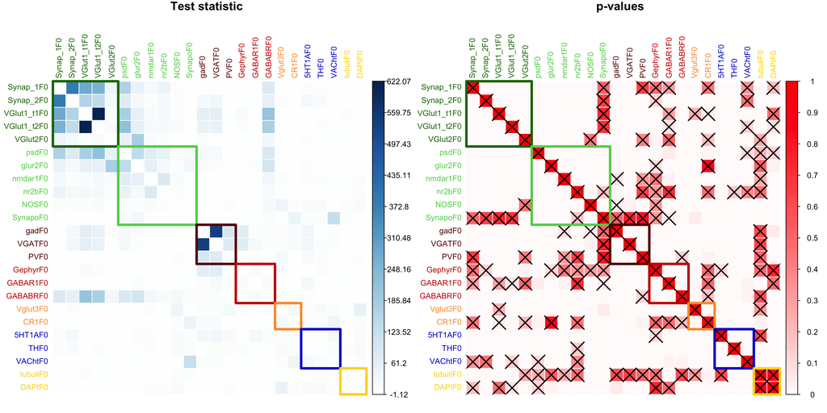

**Figure 2: F0: Distance correlation t-test statistic and p-value matrices.**

```r
cl5 <- colorRampPalette(c("white", "blue"))
bl5 <- colorRampPalette(c("blue", "red"))

par(mfrow=c(1,2))
tmp <- as.numeric(table(fchannel))
corrplot(ms[ford,ford],is.corr=FALSE,method="color",tl.col=ccol[ford],
         tl.cex=0.8, mar=c(0,0,1,0),oma=c(0,0,2,0))
title("Test statistic")
corrRect(tmp,col=Syncol,lwd=4)


corrplot((mp[ford,ford]),is.corr=FALSE,method="color",tl.col=ccol[ford],
         tl.cex=0.8,col=mycol3[-c(1:2)], mar=c(0,0,1,0),
         p.mat=mp[ford,ford], sig.level=0.05)
title("p-values")
corrRect(tmp,col=Syncol,lwd=4);rm(tmp)
```

The `X`’s in the above right figure denote a p-value greater than 0.05.

## 2.3 Scatterplots

We will run PCA on the untransformed correlation matrix so the data can be viewed in 2-dimensions. The colors correspond to synapse type.

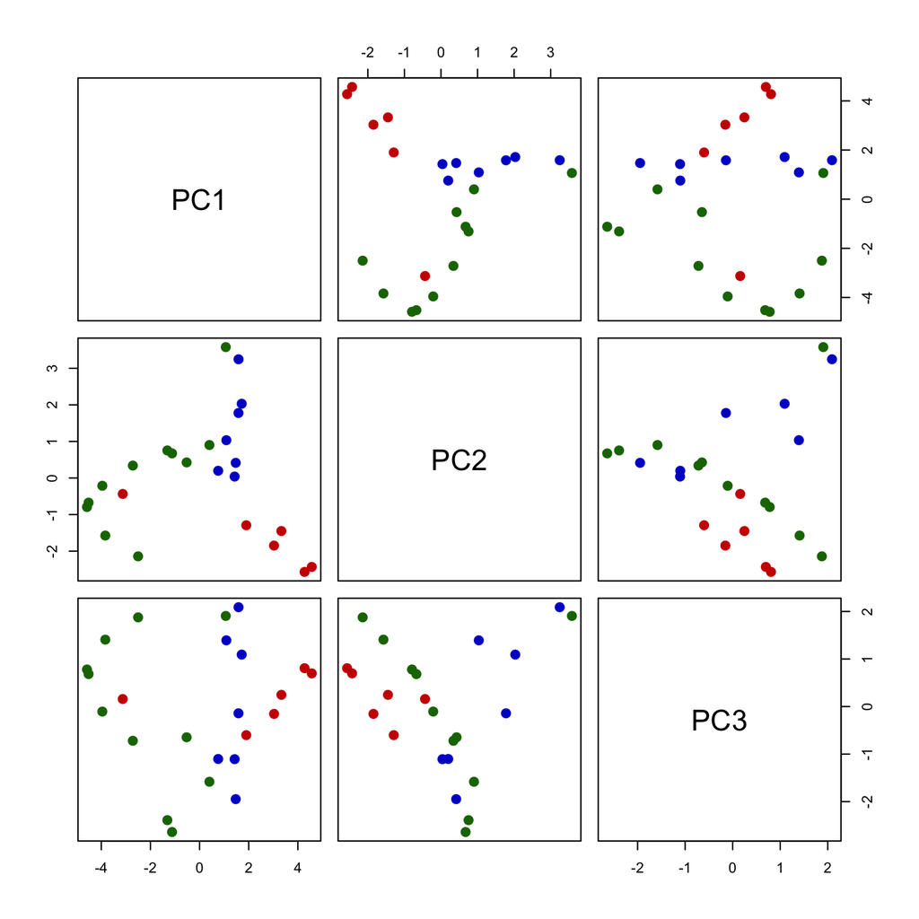

**Figure 3: PCA of untransformed correlation matrix**

```r
pca1 <- prcomp(corrf,center=TRUE, scale=TRUE)
pairs(pca1$x[,1:3], col=ccol3[ford],pch=20, cex=2)
```

```r
pca <- pca1$x
rgl::plot3d(pca[,1],pca[,2],pca[,3],type='s',col=ccol3[ford], size=1)
rgl::rgl.texts(pca[,1],pca[,2],pca[,3],abbreviate(rownames(pca)), col=ccol3[ford], adj=c(0,2))
subid <- currentSubscene3d()
rglwidget(elementId="rgl-pca1",width=720,height=720)
```

[interactive chart not shown]

```r
d1 <- data.frame(type=exType,pca1$x)
#d1 <- data.frame(type=channel.type2[ford],pca1$x)
try(lda.fit <- lda(type ~ ., data=d1),silent=FALSE)
geterrmessage()
```

```
# [1] "Error in lda.default(x, grouping, ...) : \n  variable 24 appears to be constant within groups\n"
```

```r
lda.fit <- lda(type ~ ., data=d1[,1:3])
```

LDA was run using only the first 2 out of 24 principal components from the untransformed correlation matrix.

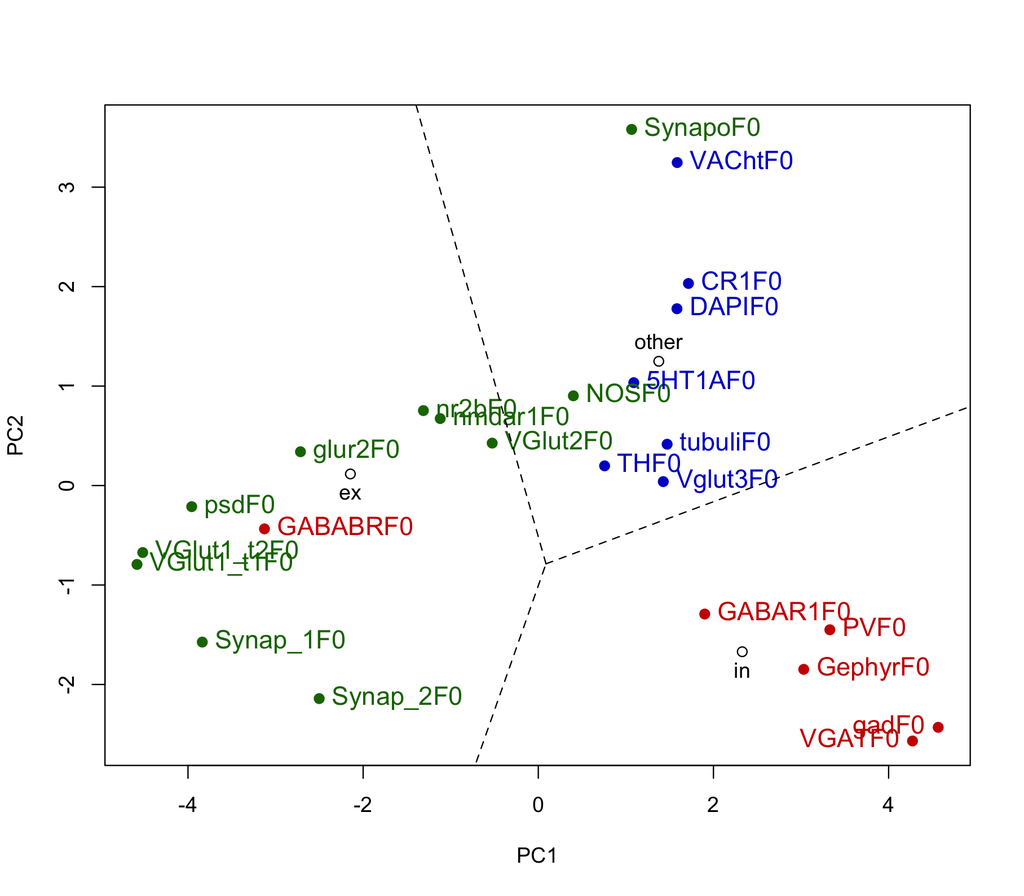

**Figure 5: Voronoi diagram on class means from LDA on PCA of untransformed correlation matrix**

```r
voronoidf <- data.frame(x=lda.fit$means[,1],y=lda.fit$means[,2])

#This creates the voronoi line segments
plot(d1[,2:3], col=ccol3[ford], pch=20, cex=1.5)

text(d1[,2:3], labels=rownames(d1), pos=ifelse(d1[,2]<4,4,2),
     col=ccol3[ford], cex=1.2)

deldir(x = voronoidf$x,y = voronoidf$y, rw = c(-5,5,-5,5),
       plotit=TRUE, add=TRUE, wl='te')
text(voronoidf, labels=rownames(voronoidf), pos=c(1,1,3))
```